# Part II - How the day of the week and hours of the day affect the number of trips and duration of trips

## Dataset Overview

> I had information about 183.412 people who used bikes. I collected details like how long their trips were and 16 other things, such as age, when they started, and when they finished. I removed the data for people with missing information and removed the outliers of duration, leaving us with 174.952 bike riders.

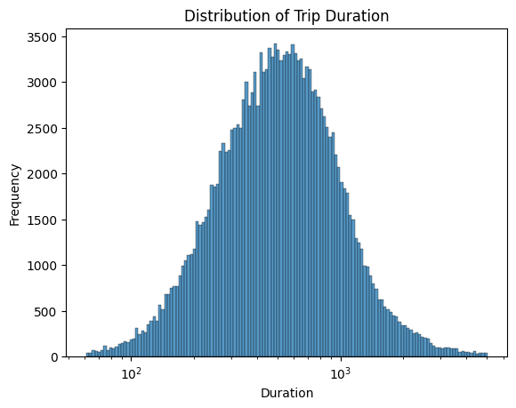

## 1- Count of Trip by Day of the Week

> To investigate the relationship between day of the week and count of trip, a bar chart was plotted. The bar charts showed that number of rides on weekends is less than weekdays.

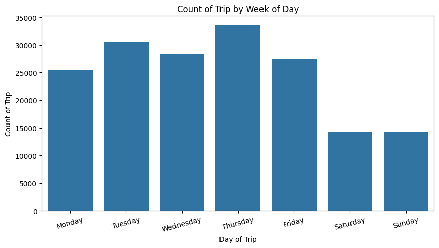

## 2- Duration of Trip by Day of Week

> To investigate the relationship between day of the week and duration of trip, a box-plot was plotted. The box-plots showed that there were many outliers in the trip duration. Thus, to get a clear visual of the relationship, we limited the number of observations to 3000 seconds. The results showed that weekdays riders completed the trip faster than weekend bike riders. In an other saying Weekned riders are more tend to enjoy their trip.

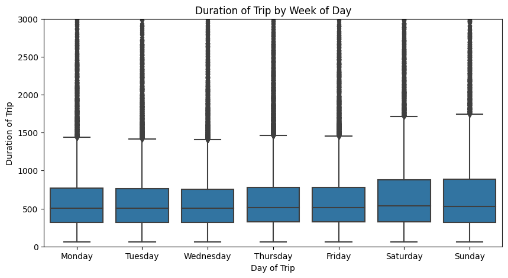

## 3- Count of Trip by Hours of Day

> To investigate the relationship between hours of the day and number of trip, a scatter was plotted. The scatter plot showed that the number of rides is highest between **10:00 and 16:00** on weekends. Additionally, The number of rides is highest between **07:00 - 9:00 and 16:00 - 18:00** on weekdays.

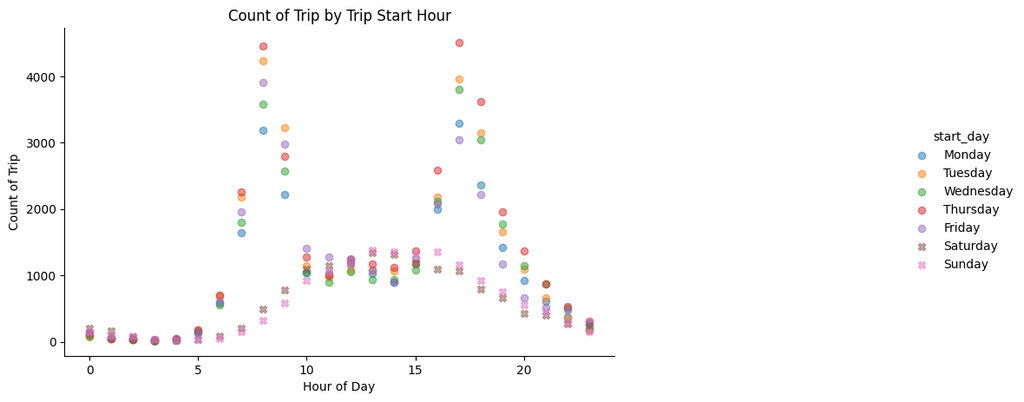

## 4- Duration of Trip by Hour of Day

> To investigate the relationship between hours of the day and duration of trip, a scatter was plotted. We know that, weekends have high duration than weekdays. Even the number of rides is highest between **10:00 and 16:00** on weekends, high duraiton time is between **10:00 - 16:00 and 04:00 - 06:00**. Additionally, even the number of rides is highest between **07:00 - 9:00 and 16:00 - 18:00** on weekdays, high duraiton time is between **11:00 - 15:00 and 01:00 - 02:00**.

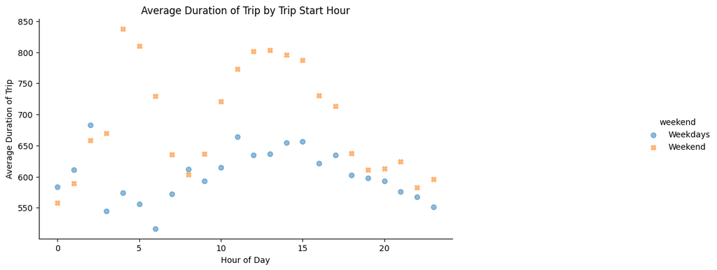

## Overall Conclusion

> Investigated the relationship between day of the week and duration / number of trip. The results showed that weekdays riders completed the trip faster than weekend bike riders. And number of ride at weekend is less than weekdays. It implies that weekned riders are more tend to enjoy their trip.

> Second investigation was about relationship between hours of the day and duration of trip. Even the number of rides is highest between **10:00 and 16:00** on weekends, high duraiton time is between **10:00 - 16:00 and 04:00 - 06:00**. Additionally, even the number of rides is highest between **07:00 - 9:00 and 16:00 - 18:00** on weekdays, high duraiton time is between **11:00 - 15:00 and 01:00 - 02:00**. The longer driving time after midnight may be due to the inaccessibility of public transportation.